# Exploratory Data Analysis: Findings Report

**Project:** FurnisherSurrogate — surrogate model for furniture placement quality scores

**Dataset:** 8,322 apartments / 45,880 active rooms from the SpatialTimber Furnisher

**Date:** February 2026

## 1. Dataset Overview

The dataset contains procedurally generated apartment layouts evaluated by a furnisher algorithm. Each apartment has 3–9 rooms; each room receives an independent placement quality score (0–100).

| Metric | Value |
| --- | --- |
| Apartments | 8,322 |
| Active rooms | 45,880 |
| Apartment types | 7 (Studio through 5-Bedroom) |
| Room types | 9 (Bedroom, Living room, Bathroom, WC, Kitchen, Children 1–4) |
| Score range | 0–100 (integer-like, 0 = complete failure) |
| Polygon format | Closed 2D polylines, 4–8 unique vertices |

**Sanity checks passed:** no missing scores, all polygons closed, all doors on wall, all scores in [0, 100]. Vertex counts are exclusively 4, 6, or 8 — corresponding to rectangles, L-shapes, and more complex notched rooms.

## 2. Score Distribution

The score distribution is strongly bimodal: rooms either fail completely (score = 0) or score well (above 70). The middle range is sparsely populated.

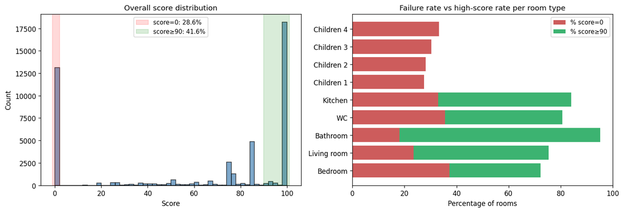

```
  Room type    n  Mean  Median  %=0  %≥90
    Bedroom 7429  50.8    54.0 37.2  35.0
Living room 7492  64.0    95.8 23.5  51.8
   Bathroom 8322  79.2   100.0 18.0  77.1
         WC 4262  59.5    75.0 35.6  45.0
    Kitchen 8322  63.1   100.0 32.9  51.2
 Children 1 4937  57.3    76.2 27.5   0.0
 Children 2 2857  56.6    76.2 28.1   0.0
 Children 3 1622  52.2    76.2 30.3   0.0
 Children 4  637  49.3    61.2 33.3   0.0
```

## 3. Geometry Analysis

Room geometry is characterised by area, bounding-box aspect ratio, and vertex count (shape complexity).

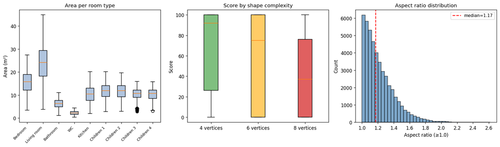

**Key observations:**

- **Room sizes** span a wide range: WC as small as 0.4 m\u00b2, living rooms up to 45 m\u00b2.
- **Shape complexity strongly predicts score:** 4-vertex rectangles have median score 92; 8-vertex rooms drop to median 37. The furnisher struggles with notched and L-shaped rooms.
- **Aspect ratio is nearly constant:** 91.6% of rooms have aspect ratio < 1.5 (near-square). This feature carries little discriminative power.
- Rooms have exclusively **4, 6, or 8 unique vertices** — no odd counts, no very complex polygons.

## 4. Feature-Score Relationships

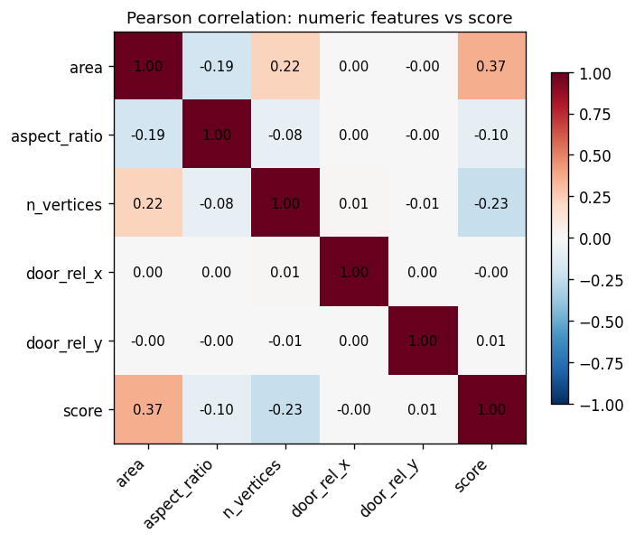

**Key observations:**

| Feature | Correlation with score | Interpretation |
| --- | --- | --- |
| area | +0.37 | Larger rooms score higher — strongest single predictor |
| n_vertices | \u22120.23 | Complex shapes score lower |
| aspect_ratio | \u22120.10 | Slight effect, mostly negligible |
| door_rel_x | \u22120.00 | No linear signal |
| door_rel_y | +0.01 | No linear signal |

- **Area explains ~13% of score variance** (r\u00b2 = 0.13). The remaining 87% comes from shape details, room type, and interactions not captured by these 5 summary statistics.
- **Door position has zero predictive power** in normalized (bounding-box-relative) form. However, the door's position *relative to the room shape* may matter — this spatial relationship requires rasterized input to capture.
- The weak linear correlations suggest the geometry\u2192score relationship is **non-linear** and **interaction-heavy** (e.g., a notch near the door matters more than a notch in a far corner).

## 5. Failure Analysis (Score = 0)

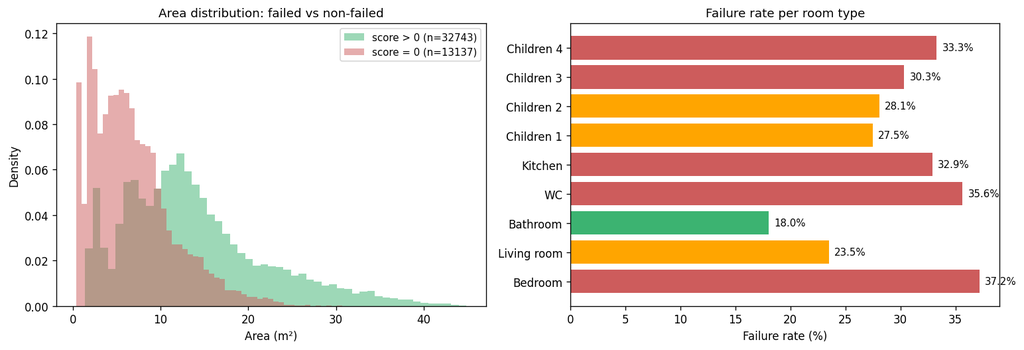

**Key observations:**

- Failed rooms are **roughly half the size** of non-failed rooms (mean 6.8 m\u00b2 vs 13.8 m\u00b2).
- Every room type has a **hard area threshold** below which the failure rate approaches 100%:

| Room type | Area threshold | Failure rate below |
| --- | --- | --- |
| Bedroom | \u2264 5.7 m\u00b2 | 100% |
| Living room | \u2264 7.3 m\u00b2 | 89% |
| Bathroom | \u2264 2.0 m\u00b2 | 100% |
| WC | \u2264 0.6 m\u00b2 | 100% |
| Kitchen | \u2264 3.2 m\u00b2 | 100% |
| Children 1\u20134 | \u2264 4.4\u20134.7 m\u00b2 | 100% |

- **Bedroom** (37.2%) and **WC** (35.6%) have the highest failure rates; **Bathroom** the lowest (18.0%).
- The sharp area thresholds suggest a two-stage modelling approach: first classify fail/pass (where area is highly predictive), then regress score for non-failed rooms.

## 6. Room Gallery

Visual comparison of high-scoring, mid-scoring, and failed rooms across all 9 room types. Polygon outline color maps from red (score = 0) through yellow to green (score = 100). Red dot marks the door.

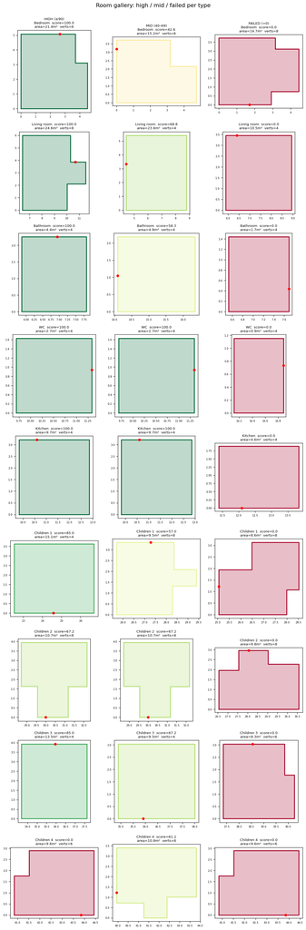

## 7. Reference Baselines

```
Naive baseline (predict room-type mean): MAE = 37.48
Inter-room score correlation within apartments: r = 0.006

Per-type baselines:
Room type         Mean    MAE
-----------------------------
Bedroom           50.8  40.08
Living room       64.0  38.93
Bathroom          79.2  31.83
WC                59.5  42.42
Kitchen           63.1  41.53
Children 1        57.3  33.14
Children 2        56.6  33.78
Children 3        52.2  34.78
Children 4        49.3  35.33
```

**Baselines to beat:**

- **Naive MAE = 37.48** — predicting the room-type mean. Any useful model must substantially beat this.
- **Inter-room correlation r = 0.006** — rooms within the same apartment have nearly independent scores. This validates the per-room prediction framing and confirms that apartment-level train/test splitting (to prevent leakage) is appropriate, though leakage risk is minimal regardless.

## 8. Implications for Modelling

### 8.1 Target distribution

The bimodal score distribution (28.6% zeros, 41.6% above 90, sparse middle) poses a challenge for standard regression. Options:

1. **Two-stage model:** classify fail/pass first (strong area signal), then regress score for non-failed rooms.
2. **Single regression** trained on the full range, accepting that the zero-spike will dominate early training.
3. **Weighted loss** that up-weights the sparse mid-range to prevent the model from collapsing to a bimodal predictor.

### 8.2 Feature signal

- **Room type** is the strongest axis of variation — drives both the score distribution shape and the area range.
- **Area** is the best single numeric predictor (r = +0.37) and explains nearly all failures below type-specific thresholds.
- **Shape complexity** (vertex count) is a strong secondary signal (8-vertex rooms: median score 37 vs 92 for rectangles).
- **Door position** has no linear predictive power in normalised form, but its spatial relationship to the room shape may matter — this requires rasterised input.
- **Aspect ratio** has minimal discriminative power (91.6% of rooms are near-square).

## 9. Data Limitations

If we decide to augment or extend the training data, these limitations should be addressed:

### 9.1 Geometric constraints

- **Only axis-aligned polygons.** All walls are horizontal or vertical. No diagonal walls, curved boundaries, or irregular angles.
- **Only 4, 6, or 8 vertices.** No rooms with 3, 5, 7, or >8 vertices exist in the dataset.
- **Counter-clockwise winding order** is assumed throughout. Clockwise or mixed-winding polygons are untested.

### 9.3 Single door per room

Every room has exactly one door. Rooms with multiple doors, no doors, or wider openings (e.g., archways) are not represented.

### 9.4 No contextual features

- Rooms are scored independently — no information about neighbouring rooms, corridors, windows, or floor-level context.
- The inter-room correlation (r = 0.006) suggests context doesn't matter for *this* furnisher, but a different scoring system might depend on apartment-level layout.

### 9.5 Apartment type distribution

- 2-Bedroom apartments are the most common (25%), 5-Bedroom the rarest (7.7%).
- Children 4 rooms appear in only 637 instances (1.4% of rooms) — predictions for this type will have higher uncertainty.

## 10. Data Distribution Boundaries

When the model fails to predict accurately, check if the input falls outside the training distribution. The table below defines the observed boundaries for each room type.

```
  Room type    n Area min Area max AR min AR max Vertices Score min Score max
    Bedroom 7429      3.4     27.4   1.00   2.24  4, 6, 8         0       100
Living room 7492      3.8     44.9   1.00   2.19  4, 6, 8         0       100
   Bathroom 8322      1.1     11.1   1.00   2.62  4, 6, 8         0       100
         WC 4262      0.4      4.3   1.00   2.38     4, 6         0       100
    Kitchen 8322      1.9     20.1   1.00   2.17  4, 6, 8         0       100
 Children 1 4937      2.8     20.1   1.00   2.13  4, 6, 8         0        85
 Children 2 2857      2.9     19.7   1.00   2.07  4, 6, 8         0        85
 Children 3 1622      2.8     16.0   1.00   2.02  4, 6, 8         0        85
 Children 4  637      3.0     15.7   1.00   2.07  4, 6, 8         0        85
```

### What is IN the distribution

The model can be expected to perform well on rooms that meet **all** of the following:

- Room type is one of the 9 known types
- Polygon is axis-aligned, closed, with 4, 6, or 8 unique vertices
- Area falls within the type-specific range shown above (e.g., Bedroom: 3.4\u201327.4 m\u00b2)
- Aspect ratio is between 1.0 and ~2.6
- Exactly one door, located on a polygon edge
- Counter-clockwise winding order

### What is OUT of the distribution

The model's predictions should not be trusted for:

- **Non-axis-aligned geometry:** diagonal walls, curved walls, irregular angles
- **Unusual vertex counts:** 3, 5, 7, or >8 vertices
- **Area outside observed range:** e.g., a 40 m\u00b2 bedroom (max observed: 27.4) or a 0.2 m\u00b2 WC (min observed: 0.4)
- **High aspect ratio:** rooms with AR > 2.6 are extrapolation territory
- **Unknown room types:** any type not in the 9 known categories
- **Multiple doors or no door**
- **Very large apartments** (>9 rooms): the dataset only covers Studio through 5-Bedroom

### Grey zones (limited coverage)

*Full analysis notebooks: 01_data_exploration.ipynb, 02_umap_exploration.ipynb*